# Students’ Preference

TUNDE Egunjobi

2023-03-28

#### **AIM**

The study aims to compare and contrast the physical and virtual learning environments based on their effect on students’ academic performance and any other related factors.

#### **Objectives**

- Exploratory Data Analysis
  - Data Visualization
- Statistical Analysis
  - Determine the effect of virtual classrooms on students’ academic performance.
  - Verify if the cost of running the two methods is the same
  - Verify if the performance of students vary by departments

#### EDA (Analysis and Visualization)

```r
#importing the necessary library
library(tidyverse)
```

```r
library(dplyr)
library(ggplot2)
library(ggrepel)
#install.packages("scales")
library(scales)
#importing the data

data<-read.csv( "my_project_data.csv")
dim(data)
```

```
## [1] 250  12
```

#### Descriptive Statistics

```r
summary(data)
```

```
##   Timestamp            Gender              Age             Department
##  Length:250         Length:250         Length:250         Length:250
##  Class :character   Class :character   Class :character   Class :character
##  Mode  :character   Mode  :character   Mode  :character   Mode  :character
##
##
##
##      Level
##  Min.   :300.0
##  1st Qu.:300.0
##  Median :400.0
##  Mean   :364.8
##  3rd Qu.:400.0
##  Max.   :400.0
##  The.average.amount.spent.in.a.week.on.physical.classes.including.transportation
##  Min.   :    0
##  1st Qu.: 1000
##  Median : 1500
##  Mean   : 2549
##  3rd Qu.: 3000
##  Max.   :15000
##  The.average.amount.spent.on.VLE.including.data.charges.per.week
##  Min.   :    0
##  1st Qu.: 1000
##  Median : 2000
##  Mean   : 3165
##  3rd Qu.: 3500
##  Max.   :30000
##  GPA.during.physical.classes GPA.during.VLE
##  Min.   :1.450               Min.   :1.500
##  1st Qu.:3.000               1st Qu.:2.850
##  Median :3.440               Median :3.330
##  Mean   :3.437               Mean   :3.311
##  3rd Qu.:3.900               3rd Qu.:3.837
##  Max.   :4.920               Max.   :4.830
##  Which.of.the.two.methods.would.you.prefer.
##  Length:250
##  Class :character
##  Mode  :character
##
##
##
##  Why.do.you.prefer.one.over.the.other. Others..specify
##  Length:250                            Length:250
##  Class :character                      Class :character
##  Mode  :character                      Mode  :character
##
##
##
```

#### Gender

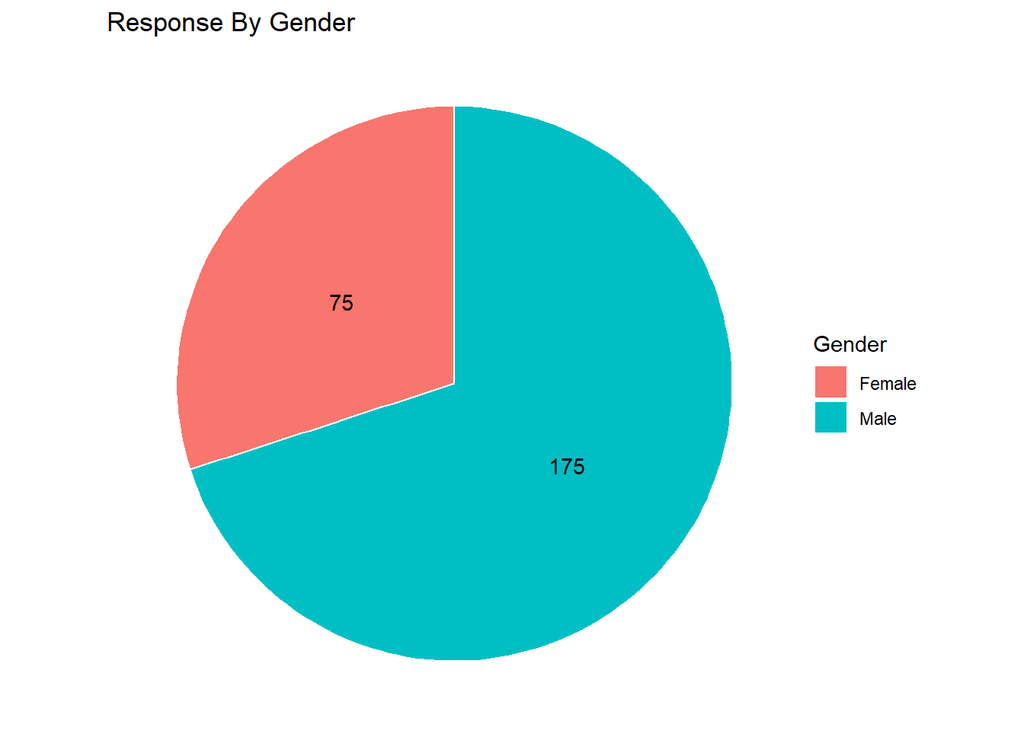

```r
pie <- ggplot(data, aes(x = "", fill = Gender)) +
  geom_bar(width = 1, color = "white") +
  coord_polar(theta = "y") +
  ggtitle("Response By Gender") +
  theme_void()

# Add labels to the pie chart
pie + geom_text(aes(label = ..count..),
                stat = "count",
                position = position_stack(vjust = 0.5))
```

##### Preference

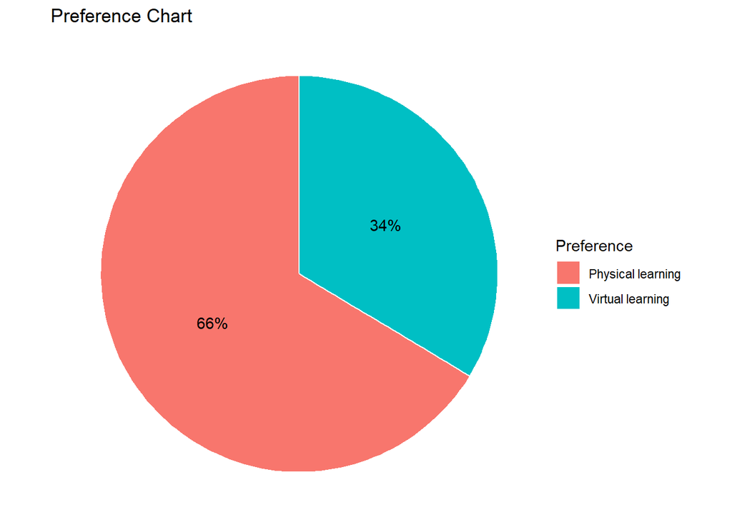

```r
pie <- ggplot(data, aes(x = "", fill = Which.of.the.two.methods.would.you.prefer.)) +
  geom_bar(width = 1, color = "white") +
  coord_polar(theta = "y") +
  ggtitle("Preference Chart") +
  labs(fill = "Preference")+
  theme_void()

# Add labels to the pie chart
pie + geom_text(aes(label = scales::percent(..count../sum(..count..))),
            stat = "count",
            position = position_stack(vjust = 0.5))
```

#### Gender by Level

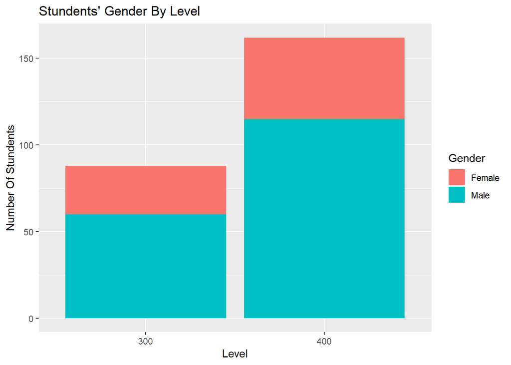

```r
ggplot(data, aes(x = factor(Level), fill = factor(Gender))) +
  geom_bar() +
  labs(title = "Stundents' Gender By Level",
       x = "Level",
       y = "Number Of Stundents") +
  scale_fill_discrete(name = "Gender")
```

#### Preference by Gender and Level

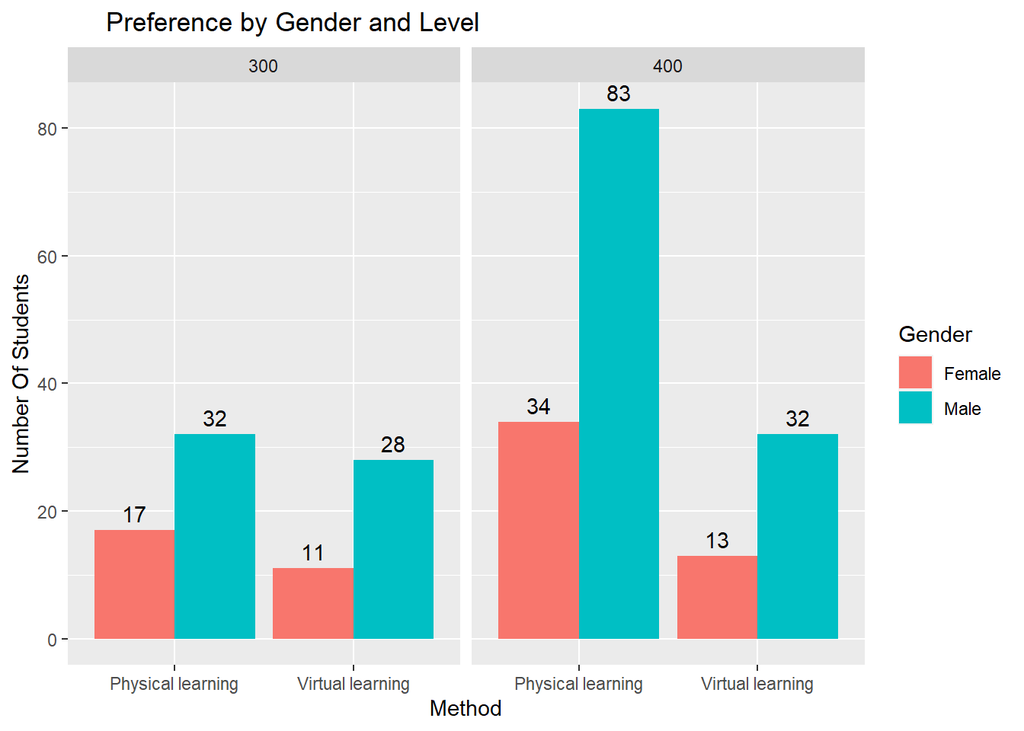

```r
ggplot(data, aes(x = Which.of.the.two.methods.would.you.prefer., fill = Gender)) +
  geom_bar(position = "dodge") +
  facet_grid(. ~ Level) +
  labs( title = "     Preference by Gender and Level", x = "Method", y = "Number Of Students", fill = "Gender") +
  stat_count(geom = "text", aes(label = ..count..), position = position_dodge(width = 0.9), vjust = -0.5)
```

#### Preference by Department

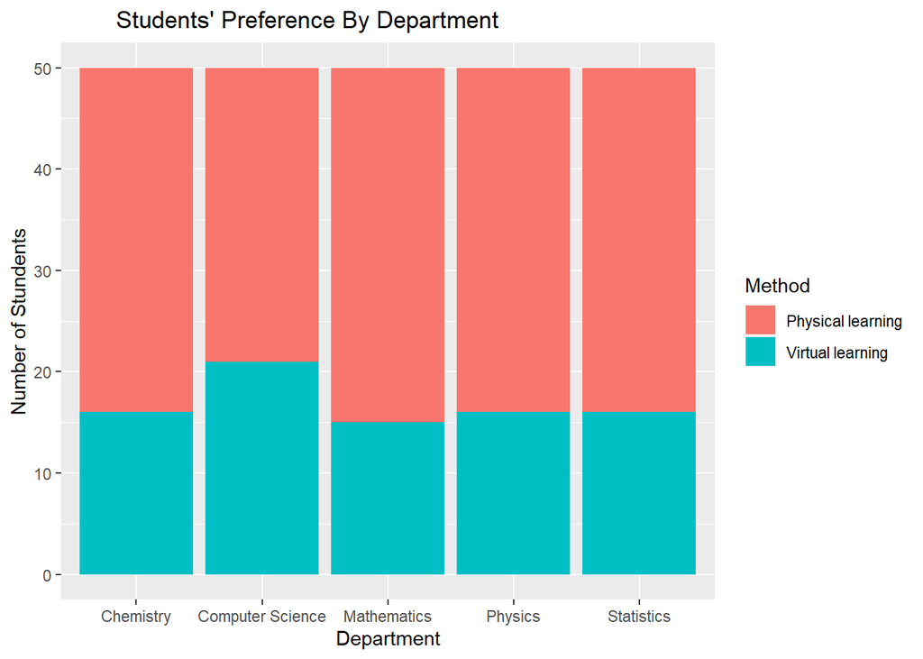

```r
ggplot(data, aes(x = factor(Department), fill = factor(Which.of.the.two.methods.would.you.prefer.)))+
  geom_bar()+
  labs(title = "        Students' Preference By Department", x= 'Department',
       y= "Number of Stundents") + scale_fill_discrete(name = "Method")
```

#### Age distribution by preference

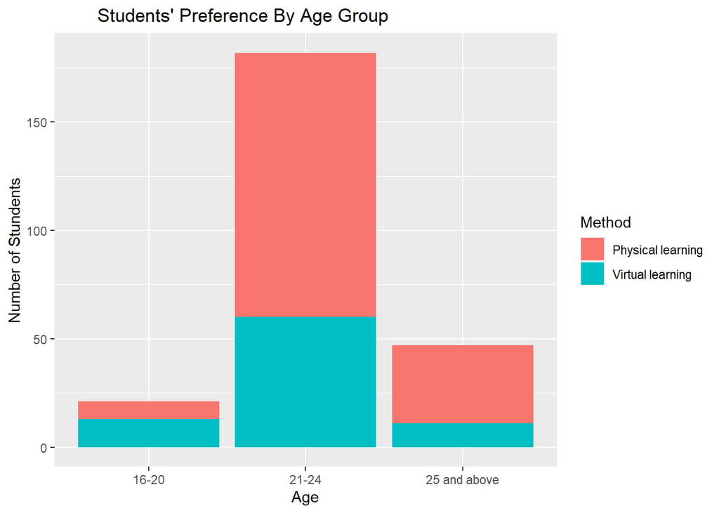

```r
ggplot(data, aes(x = factor(Age), fill = factor(Which.of.the.two.methods.would.you.prefer.)))+
  geom_bar()+
  labs(title = "        Students' Preference By Age Group", x= 'Age',
       y= "Number of Stundents") + scale_fill_discrete(name = "Method")
```

#### BOX Plot for amount Spent on the method.

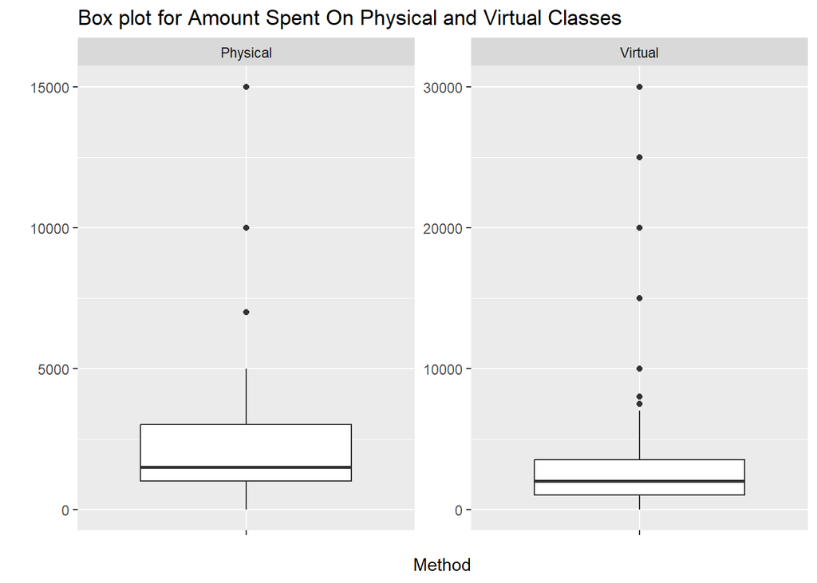

```r
dat <- data.frame(

  Physical = data$The.average.amount.spent.in.a.week.on.physical.classes.including.transportation,
  Virtual = data$The.average.amount.spent.on.VLE.including.data.charges.per.week)

# Reshape data into long format
data_long <- gather(dat, key = "column", value = "value", Physical, Virtual)
# Create combined box plot
ggplot(data_long, aes(x = '', y = value)) +
  geom_boxplot() +
  facet_wrap(~ column, scales = "free_y") +
  labs(x = "Method", y = "") +
  ggtitle("Box plot for Amount Spent On Physical and Virtual Classes")
```

#### CGPA by preference

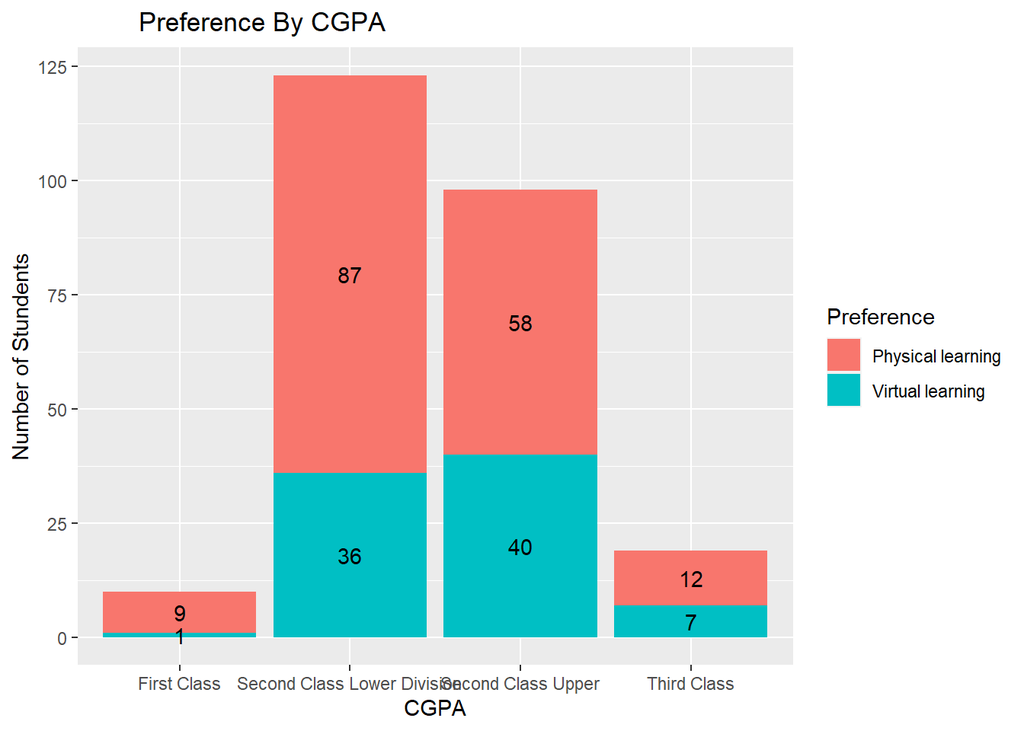

```r
data <- data %>%
  mutate(CGPA = (GPA.during.physical.classes + GPA.during.VLE ) / 2) %>%
  mutate(CGPA = case_when(
    CGPA >= 4.5 ~ "First Class",
    CGPA >= 3.5 & CGPA < 4.5  ~ "Second Class Upper",
    CGPA >= 2.5 & CGPA < 3.5  ~ "Second Class Lower Division",
    CGPA >= 1.5 & CGPA <2.5  ~ "Third Class",
    CGPA < 1.5  ~ "Pass",
  ))

ggplot(data, aes(x = CGPA, fill = Which.of.the.two.methods.would.you.prefer.)) +
  geom_bar() +
  labs(title = "        Preference By CGPA", x= 'CGPA', fill = 'Preference',
       y= "Number of Stundents") +
  geom_text(aes(label = ..count..),
                  stat = "count",
                  position = position_stack(vjust = 0.5))
```

#### First_class per Department

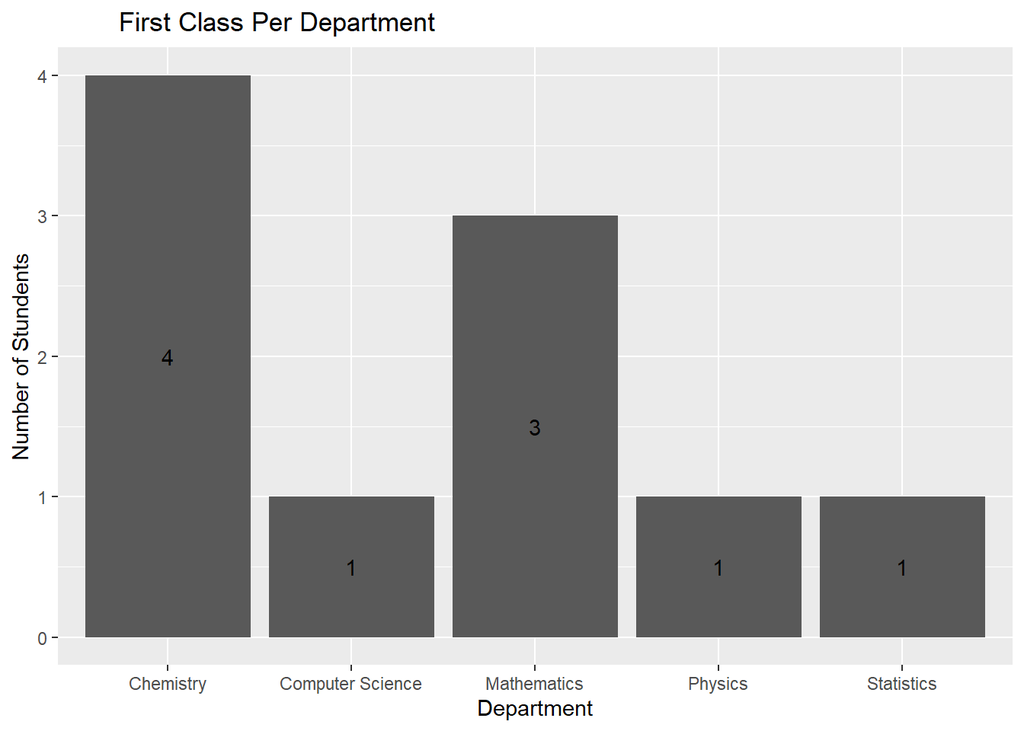

```r
first_class = data[data$CGPA == 'First Class',]

ggplot(first_class, aes(x= Department))+geom_bar()+
  labs(title = "        First Class Per Department",
       y= "Number of Stundents", color = 'red') +
  geom_text(aes(label = ..count..),
            stat = "count",
            position = position_stack(vjust = 0.5))
```

### Statistics Analysis

#### Data Cleaning

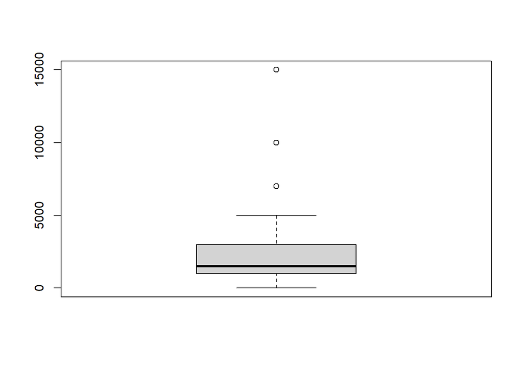

```r
# Identify outlier values using boxplot
outlier <- boxplot(data$The.average.amount.spent.in.a.week.on.physical.classes.including.transportation)$out
```

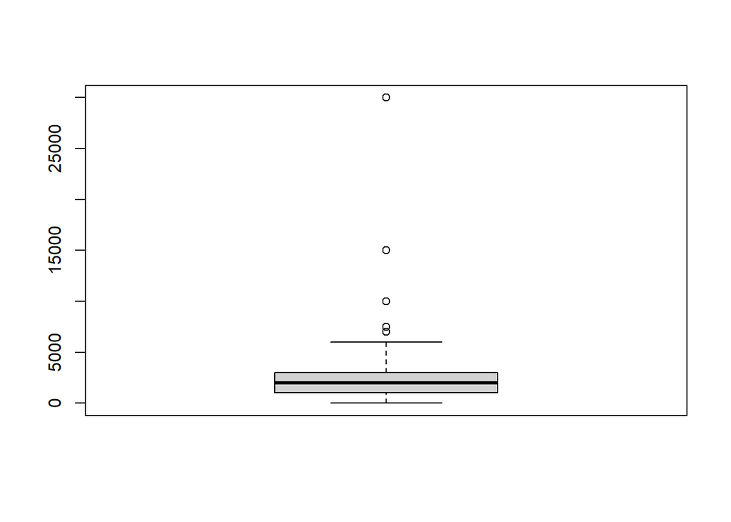

```r
# Remove rows with outlier values (The Amount ROWs)
mydata <- subset(data, !The.average.amount.spent.in.a.week.on.physical.classes.including.transportation %in% outlier)
outlier2 <- boxplot(mydata$The.average.amount.spent.on.VLE.including.data.charges.per.week)$out
```

```r
# Remove rows with outlier values
mydata <- subset(mydata,!The.average.amount.spent.on.VLE.including.data.charges.per.week %in% outlier2)
dim(mydata)
```

```
## [1] 225  13
```

#### Paired T Test for GPA

##### (Determine the effect of virtual classrooms on students’ academic performance.)

- Hypothesis:
  - H0: There is no significant difference in the performance of students before and after the virtual learning.
  - H1: There is significant difference in the performance of students before and after the virtual learning.

```r
t.test(data$GPA.during.physical.classes, data$GPA.during.VLE, paired = TRUE, conf.level = 0.95)
```

```
##
##  Paired t-test
##
## data:  data$GPA.during.physical.classes and data$GPA.during.VLE
## t = 3.8774, df = 249, p-value = 0.0001351
## alternative hypothesis: true mean difference is not equal to 0
## 95 percent confidence interval:
##  0.0620773 0.1902427
## sample estimates:
## mean difference
##         0.12616
```

Interpretation: The p-value (0.0001351) < 0.05, which implies that we fail to accept the null hypothesis i.e. There is significant difference in Students’ Performance before and after the Virtual Class

#### Difference of two means for amount

##### (To Verify if the cost of running the two methods is the same)

- Hypothesis:
  - H0: There is no significant difference in the cost of running the two methods.
  - H1: There is significant difference in the cost of running the two methods.

```r
t.test(mydata$The.average.amount.spent.in.a.week.on.physical.classes.including.transportation , data$The.average.amount.spent.on.VLE.including.data.charges.per.week , paired = FALSE, conf.level = 0.95)
```

```
##
##  Welch Two Sample t-test
##
## data:  mydata$The.average.amount.spent.in.a.week.on.physical.classes.including.transportation and data$The.average.amount.spent.on.VLE.including.data.charges.per.week
## t = -5.0791, df = 296.81, p-value = 6.713e-07
## alternative hypothesis: true difference in means is not equal to 0
## 95 percent confidence interval:
##  -1892.2283  -835.3717
## sample estimates:
## mean of x mean of y
##    1801.2    3165.0
```

Interpretation: The p-value < 0.05, which implies that we fail to accept the null hypothesis i.e. There is significant difference in the cost of running the two methods

#### Anova (Verify if the performance of students vary by departments)

+Hypothesis:

- H0: Performance Of Student are the same across the departments
- H1: Performance Of Student are not the same across the departments

```r
#Performance by Department
sts =subset(data,Department=='Statistics')
mts =subset(data,Department=='Mathematics')
chm =subset(data,Department=='Chemistry')
phs =subset(data,Department=='Physics')
csc =subset(data,Department=='Computer Science')


#physical
department = c(rep('sts', 50), rep('mts', 50),rep('chm', 50),rep('phs', 50)
               ,rep('csc', 50))
gpa = c(sts$GPA.during.physical.classes,mts$GPA.during.physical.classes,chm$GPA.during.physical.classes,
        phs$GPA.during.physical.classes,csc$GPA.during.physical.classes)
dept = data.frame(department,gpa)
dept_analysis<- aov(gpa~department, data = dept)
summary(dept_analysis)
```

```
##              Df Sum Sq Mean Sq F value Pr(>F)
## department    4   0.88  0.2196   0.536   0.71
## Residuals   245 100.41  0.4098
```

```r
#virtual

department = c(rep('sts', 50), rep('mts', 50),rep('chm', 50),rep('phs', 50)
               ,rep('csc', 50))
gpa_v = c(sts$GPA.during.VLE,mts$GPA.during.VLE,chm$GPA.during.VLE,
          phs$GPA.during.VLE,csc$GPA.during.VLE)
dept_v = data.frame(department,gpa_v)
dept_analysis_v<- aov(gpa_v~department, data = dept_v)
summary(dept_analysis_v)
```

```
##              Df Sum Sq Mean Sq F value Pr(>F)
## department    4    3.1  0.7746   1.447  0.219
## Residuals   245  131.2  0.5355
```

Interpretation: From the two tests above the p-value > 0.05, which implies that we accept the null hypothesis i.e. There is no significant difference in the Performance of Student across departments for the two methods of Learning.

### Summary Of Findings

- The newly adopted virtual classroom has an adverse effect on students academic performance
- The cost of running the method is different significantly from the regular method (Physical Classrooms)
- The ratio of preference of physical classroom to virtual is 2 to 1

### Conclusion

Based on the result obtained, we can conclude that the newly (Virtual) adopted method has effect on students’ academic performance and the cost of running the method is not the same with the physical classroom method.

### Recommendation

The country’s education system is not ready to be digitalized completely or moved to Virtual learning, as the system cannot guarantee the effectiveness of the method. Hence, physical classes should continue and the school may consider mixed method which will be more physical than virtual to prepare the students for outside school and to avoid the loss of knowledge.